# index

[Uzezi Okinedo](https://uzezi93.github.io/uzezi-okinedo/)

[figure not shown]

[figure not shown]

[figure not shown]

[figure not shown]

## About Me

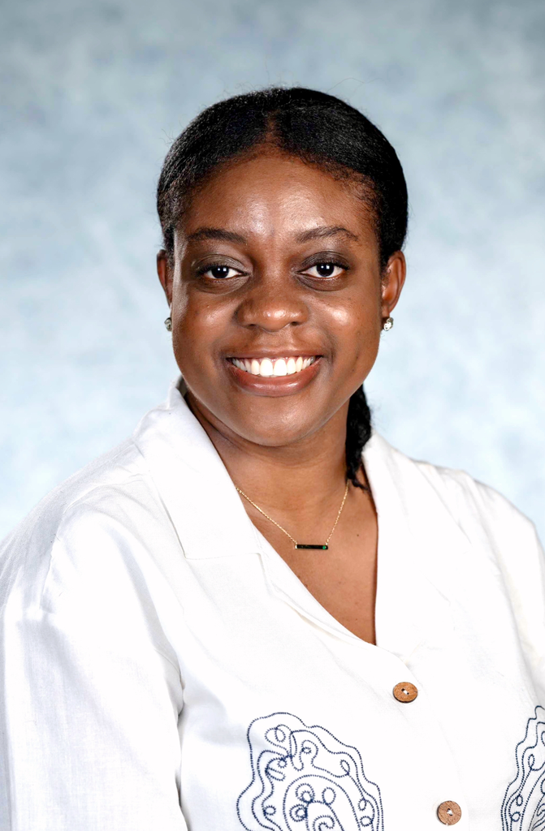

I am a Biology Ph.D. candidate in the [Moyers Lab](https://www.brookmoyers.com) at the University of Massachusetts Boston. My research focuses on plant genomics and evolutionary biology, with a particular interest in understanding the genetic basis of trait variation and how plants adapt to diverse environments. I hold a Bachelor’s of Science degree in Cell Biology and Genetics and a Master’s of Science degree in Cell and Molecular Biology from the University of Lagos, earned in 2016 and 2019, respectively.

Currently, I am a Global Rice Research Foundation (GRRF) leadership fellow and a recipient of the International Rice Research Institute (IRRI) MSI scholarship. As part of the IRRI MSI program, I contribute to a project that assesses genetic basis of iron deficiency tolerance in rice varieties from the IRRI gene bank. My expertise spans computational genomics, evolutionary biology, quantitative genetics, and, more recently, AI-based predictive modeling.

## Research Interests

My research focuses on the genetic architecture of complex traits and the phenotypic responses of plants to diverse environments. I use computational genomics, computer vision techniques, and evolutionary models to explore how plants adapt to varying conditions and to uncover the genetic basis of trait variation. My primary research is on rice, where I have completed projects investigating the genetic basis of seed trait variation through computer vision-based phenotyping. Other projects include examining how genetic variation influences rice reproductive traits under heat stress and tolerance to iron deficiency under Direct-Seeded conditions. Additionally, I research Silverleaf sunflowers, exploring how gene pleiotropy contributes to their environmental adaptation.

In summary, my research interest include:

- **Genetic Basis of Traits and Adaptation**:  
  Exploring the genetic architecture of complex traits and plant adaptation to environmental stressors like heat and nutrient deficiencies.
- **Genomics and Phenotyping Tools**:  
  Utilizing computational genomics, computer vision, and evolutionary models to understand trait variation and improve plant phenotyping.

## Awards & Recognition

##### **2024**

- **[Global Rice Research Foundation (GRRF) Leadership Award](https://ricefound.org/award-winners/)** ($7,150).

##### **2023**

- **International Rice Research Institute (IRRI) MSI Scholarship** by USAID (~ $45,000).
- **UMass Boston Nancy Goranson Endowment Fund** ($735).
- **[Best Poster Presentation](https://botany.org/home/awards/annual-award-recipients/2023-award-recipients.html)**, Economic Botany Section - Botany 2023, Boise, Idaho.
- **[Association for Women in Science (AWIS) Distinguished Dissertation Research Scholarship](https://awis.org/scholarships/)** ($10,000).
- **Corteva Showcase Award**.
- **[Botanical Society of America (BSA) Genetics Section Student Travel Award](https://botany.org/home/awards/annual-award-recipients/2023-award-recipients.html)** ($500).
- **American Society of Plant Biologists (ASPB) Recognition Travel Award**.
- **Herbert Lipke Memorial Endowment Fund** ($1,000).
- **[Cold Spring Harbor Laboratory (CSHL) Financial Award](https://meetings.cshl.edu/alumni.aspx?course=C-PLAN&year=18)** for course attendance ($3,000).

##### **2022**

- **[Honorable Mention](https://www.gwis.org/page/past_fellowships)** by Graduate Women in Science (GWIS) National Fellowship.
- **[Genetics Society of America (GSA) DeLill Nasser Award](https://genestogenomes.org/congratulations-to-the-spring-2022-delill-nasser-awardees/)** for Professional Development in Genetics ($1,000).
- **[American Association of University Women (AAUW) International Doctoral Fellowship](https://www.aauw.org/fellowships_directory/#rid6616)** ($20,000).

##### **2021**

- **Summer Institute of Statistical Genetics (SISG) Scholarship Recipient**.

##### **2019**

- **[EducationUSA Opportunity Fund Scholar](https://thenationonlineng.net/u-s-opportunity-funds-scholars-share-experience/#google_vignette)**.
- **Dr. D.K Olukoya Academic Award of Excellence**.

##### **2016**

- **First Class Honors** (Cell Biology and Genetics).

##### **2012 – 2015**

- **University of Lagos Endowment Award** for Academic Excellence (2012/2013, 2013/2014, 2014/2015).

##### **2014**

- **Mountain of Fire and Miracles Ministries Acknowledgement** of Academic Excellence.

##### **2013**

- **Science Student Fellowship (SSF) Award** for Academic Excellence.

[figure not shown]

[figure not shown]

[figure not shown]

[figure not shown]